# Held-out evaluation of the SingleR and scANVI AML references

JN Taroni

2026

## Introduction

Both references were trained **without** one study (`params$holdout_study`, mumme_2023 by default) and then used to label that study’s cells:

- **SingleR:** `04_predict-holdout-singler.R`, with the `_no-<study>` trained reference.
- **scANVI:** `04_predict-holdout-scanvi.py`, scArches query mapping with the true labels hidden.

This notebook compares those predictions with the atlas labels. It only reads results, so it re-knits quickly; produce them with `run-holdout-eval.sh`.

Things to keep in mind while reading:

- mumme_2023 contains the atlas’s only 10x 5′ data. The held-out models therefore saw **no** 5′ cells in training, so 5′ scores are a pessimistic lower bound for ScPCA SCPCP000007 (all 10x v2 5′). Every metric is split by assay.
- mumme_2023 has no healthy donors.
- “Truth” is the atlas annotation, which is itself a prediction from the atlas authors.
- The main metrics use every cell, with SingleR’s **unpruned** labels; the confidence section looks at pruning and probability thresholds.

## Setup

```r
suppressPackageStartupMessages({
  library(dplyr)
  library(ggplot2)
})

holdout_study <- params$holdout_study

root_dir <- rprojroot::find_root(rprojroot::has_dir(".git"))
module_dir <- fs::path(root_dir, "analyses", "annotate-aml")
atlas_file <- fs::path(root_dir, "data", "AML-scAtlas", "AML_scAtlas_le29.h5ad")
holdout_dir <- fs::path(module_dir, "results", "holdout")
singler_file <- fs::path(holdout_dir, paste0("singler_predictions_", holdout_study, ".tsv"))
scanvi_file <- fs::path(holdout_dir, paste0("scanvi_predictions_", holdout_study, ".tsv"))

stopifnot(
  fs::file_exists(atlas_file),
  fs::file_exists(singler_file),
  fs::file_exists(scanvi_file)
)

# Plot style, metric and plotting functions shared with 06_compare-bonemarrowmap-holdout.Rmd
source(fs::path(module_dir, "utils", "eval-helpers.R"))
```

Plot styling: color always identifies the **method** (categorical slots 1 and 2 of the reference palette); assays are separate panels. Heatmaps use a single blue ramp.

```r
method_colors <- method_colors_all[c("SingleR", "scANVI")]
theme_set(eval_theme())
scale_color_method <- scale_color_manual(values = method_colors, name = "Method")
```

## Load truth and predictions

True labels, assay and donor for the held-out cells, from the atlas subset (metadata only).

```r
adata <- anndataR::read_h5ad(atlas_file, as = "HDF5AnnData")
obs <- adata$obs
obs$cell_id <- adata$obs_names
rm(adata)

# label_fine -> label_broad map; each fine class belongs to exactly one broad class
label_map <- obs |>
  distinct(label_fine = as.character(label_fine), label_broad = as.character(label_broad))
stopifnot(!anyDuplicated(label_map$label_fine))

truth <- obs |>
  filter(Study == holdout_study) |>
  transmute(
    cell_id,
    donor_id = as.character(donor_id),
    sample = as.character(Sample),
    assay = as.character(assay),
    true_fine = as.character(label_fine),
    true_broad = as.character(label_broad)
  )

nrow(truth)
```

```
[1] 46588
```

```r
count(truth, assay)
```

| assay | n |
| --- | --- |
| 10x 3' v3 | 16119 |
| 10x 5' v1 | 30469 |

Predictions from both methods, in one long table (one row per cell per method).

```r
singler <- data.table::fread(singler_file, data.table = FALSE)
scanvi <- data.table::fread(scanvi_file, data.table = FALSE)

stopifnot(
  setequal(singler$cell_id, truth$cell_id),
  setequal(scanvi$cell_id, truth$cell_id)
)

predictions <- bind_rows(
  singler |> transmute(cell_id, method = "SingleR", pred_fine = singler_label),
  scanvi |> transmute(cell_id, method = "scANVI", pred_fine = scanvi_label)
) |>
  left_join(label_map, by = c("pred_fine" = "label_fine")) |>
  rename(pred_broad = label_broad) |>
  inner_join(truth, by = "cell_id") |>
  mutate(method = factor(method, levels = names(method_colors)))

stopifnot(!anyNA(predictions$pred_broad))
```

Long format by label level, used by every metric below.

```r
by_level <- bind_rows(
  predictions |> transmute(cell_id, method, assay, donor_id,
                           level = "label_broad", truth = true_broad, pred = pred_broad),
  predictions |> transmute(cell_id, method, assay, donor_id,
                           level = "label_fine", truth = true_fine, pred = pred_fine)
) |>
  mutate(
    level = factor(level, levels = c("label_broad", "label_fine")),
    correct = truth == pred
  )
```

## Metric helpers

Per-label precision, recall and F1 within a group of cells. Labels are those present in the truth for that group; precision counts every cell predicted as the label.

```r
# per_label_metrics() is defined in utils/eval-helpers.R
label_metrics <- by_level |>
  group_by(method, assay, level) |>
  group_modify(\(df, key) per_label_metrics(df)) |>
  ungroup()
```

## Overall performance

Accuracy and macro-F1 (the unweighted mean of per-label F1, so rare labels count as much as common ones) for each method, assay and label level.

```r
overall <- overall_metrics(by_level, label_metrics)

overall |>
  arrange(level, assay, method) |>
  knitr::kable(digits = 3)
```

| method | assay | level | n_cells | accuracy | macro_f1 |
| --- | --- | --- | --- | --- | --- |
| SingleR | 10x 3’ v3 | label_broad | 16119 | 0.652 | 0.659 |
| scANVI | 10x 3’ v3 | label_broad | 16119 | 0.704 | 0.657 |
| SingleR | 10x 5’ v1 | label_broad | 30469 | 0.534 | 0.654 |
| scANVI | 10x 5’ v1 | label_broad | 30469 | 0.614 | 0.682 |
| SingleR | 10x 3’ v3 | label_fine | 16119 | 0.623 | 0.373 |
| scANVI | 10x 3’ v3 | label_fine | 16119 | 0.680 | 0.416 |
| SingleR | 10x 5’ v1 | label_fine | 30469 | 0.439 | 0.403 |
| scANVI | 10x 5’ v1 | label_fine | 30469 | 0.522 | 0.442 |

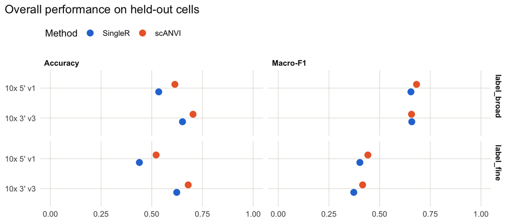

```r
overall |>
  tidyr::pivot_longer(c(accuracy, macro_f1), names_to = "metric") |>
  mutate(metric = recode(metric, accuracy = "Accuracy", macro_f1 = "Macro-F1")) |>
  ggplot(aes(x = value, y = assay, color = method)) +
  geom_point(size = 3, position = position_dodge(width = 0.5)) +
  facet_grid(level ~ metric) +
  scale_x_continuous(limits = c(0, 1), breaks = seq(0, 1, 0.25)) +
  scale_color_method +
  labs(x = NULL, y = NULL, title = "Overall performance on held-out cells")
```

## Per-label performance

F1 for each label, by assay. Point size shows the number of true cells in that label, so labels with few cells (noisy F1) are easy to spot.

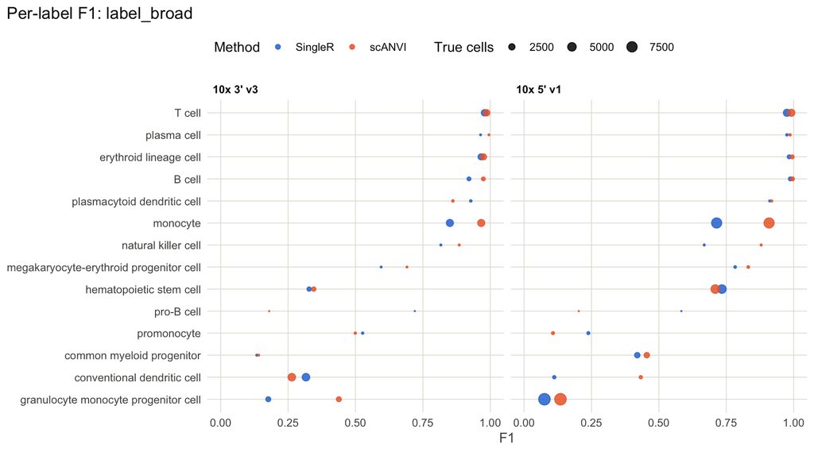

```r
plot_per_label(label_metrics, "label_broad", scale_color_method)
```

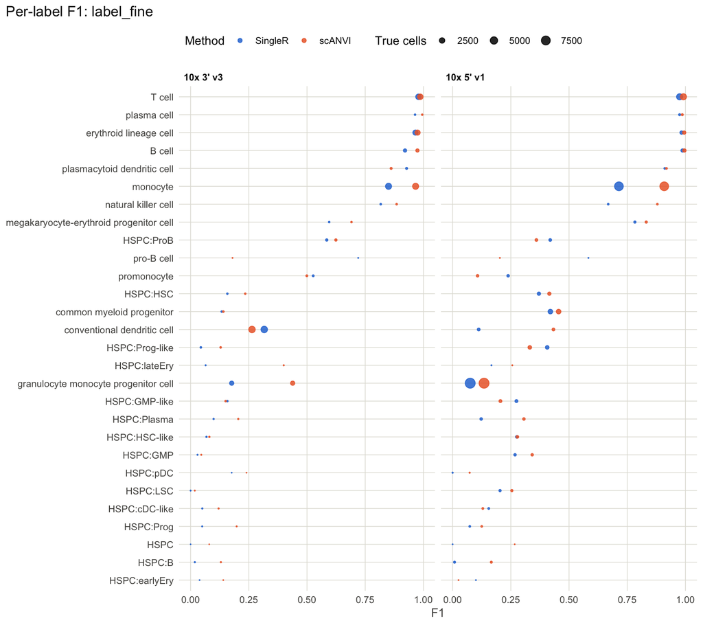

```r
plot_per_label(label_metrics, "label_fine", scale_color_method)
```

Full per-label table:

```r
label_metrics |>
  arrange(level, label, assay, method) |>
  knitr::kable(digits = 3)
```

| method | assay | level | label | n_cells | precision | recall | f1 |
| --- | --- | --- | --- | --- | --- | --- | --- |
| SingleR | 10x 3’ v3 | label_broad | B cell | 780 | 0.869 | 0.979 | 0.921 |
| scANVI | 10x 3’ v3 | label_broad | B cell | 780 | 0.974 | 0.974 | 0.974 |
| SingleR | 10x 5’ v1 | label_broad | B cell | 811 | 0.982 | 0.994 | 0.988 |
| scANVI | 10x 5’ v1 | label_broad | B cell | 811 | 0.999 | 0.993 | 0.996 |
| SingleR | 10x 3’ v3 | label_broad | T cell | 2607 | 0.983 | 0.975 | 0.979 |
| scANVI | 10x 3’ v3 | label_broad | T cell | 2607 | 0.989 | 0.985 | 0.987 |
| SingleR | 10x 5’ v1 | label_broad | T cell | 3340 | 0.995 | 0.956 | 0.975 |
| scANVI | 10x 5’ v1 | label_broad | T cell | 3340 | 0.992 | 0.990 | 0.991 |
| SingleR | 10x 3’ v3 | label_broad | common myeloid progenitor | 121 | 0.078 | 0.479 | 0.134 |
| scANVI | 10x 3’ v3 | label_broad | common myeloid progenitor | 121 | 0.091 | 0.306 | 0.141 |
| SingleR | 10x 5’ v1 | label_broad | common myeloid progenitor | 1763 | 0.391 | 0.453 | 0.420 |
| scANVI | 10x 5’ v1 | label_broad | common myeloid progenitor | 1763 | 0.769 | 0.323 | 0.455 |
| SingleR | 10x 3’ v3 | label_broad | conventional dendritic cell | 3812 | 0.480 | 0.236 | 0.316 |
| scANVI | 10x 3’ v3 | label_broad | conventional dendritic cell | 3812 | 0.826 | 0.157 | 0.264 |
| SingleR | 10x 5’ v1 | label_broad | conventional dendritic cell | 532 | 0.060 | 0.936 | 0.112 |
| scANVI | 10x 5’ v1 | label_broad | conventional dendritic cell | 532 | 0.286 | 0.891 | 0.433 |
| SingleR | 10x 3’ v3 | label_broad | erythroid lineage cell | 2265 | 0.986 | 0.946 | 0.966 |
| scANVI | 10x 3’ v3 | label_broad | erythroid lineage cell | 2265 | 0.995 | 0.956 | 0.975 |
| SingleR | 10x 5’ v1 | label_broad | erythroid lineage cell | 830 | 0.995 | 0.972 | 0.984 |
| scANVI | 10x 5’ v1 | label_broad | erythroid lineage cell | 830 | 0.995 | 0.994 | 0.995 |
| SingleR | 10x 3’ v3 | label_broad | granulocyte monocyte progenitor cell | 1441 | 0.898 | 0.098 | 0.176 |
| scANVI | 10x 3’ v3 | label_broad | granulocyte monocyte progenitor cell | 1441 | 0.772 | 0.306 | 0.438 |
| SingleR | 10x 5’ v1 | label_broad | granulocyte monocyte progenitor cell | 9611 | 0.828 | 0.040 | 0.075 |
| scANVI | 10x 5’ v1 | label_broad | granulocyte monocyte progenitor cell | 9611 | 0.828 | 0.073 | 0.135 |
| SingleR | 10x 3’ v3 | label_broad | hematopoietic stem cell | 1025 | 0.202 | 0.874 | 0.328 |
| scANVI | 10x 3’ v3 | label_broad | hematopoietic stem cell | 1025 | 0.212 | 0.922 | 0.345 |
| SingleR | 10x 5’ v1 | label_broad | hematopoietic stem cell | 5061 | 0.604 | 0.936 | 0.734 |
| scANVI | 10x 5’ v1 | label_broad | hematopoietic stem cell | 5061 | 0.573 | 0.930 | 0.709 |
| SingleR | 10x 3’ v3 | label_broad | megakaryocyte-erythroid progenitor cell | 106 | 0.806 | 0.472 | 0.595 |
| scANVI | 10x 3’ v3 | label_broad | megakaryocyte-erythroid progenitor cell | 106 | 0.607 | 0.802 | 0.691 |

[output cut: 138 more lines]

## Confusion matrices

Rows are true labels and are normalized to sum to 1, so each row shows where that label’s cells went; a perfect method is a dark diagonal. Blank cells are 0. Only shares of at least 0.2 are labeled.

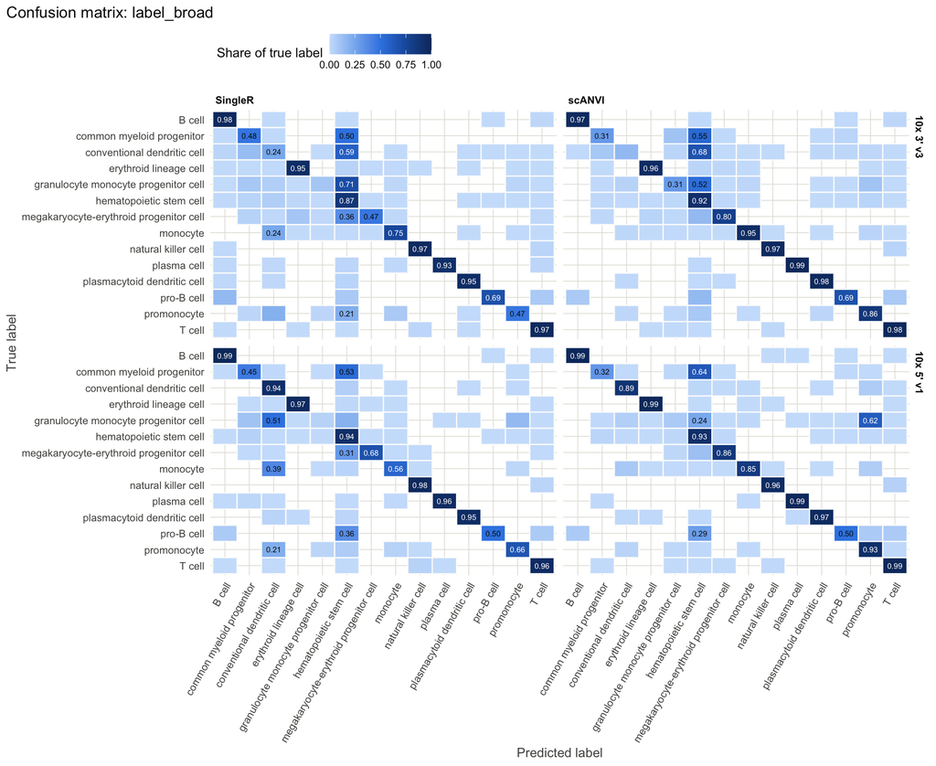

```r
by_level |>
  filter(level == "label_broad") |>
  plot_confusion("Confusion matrix: label_broad")
```

At the fine level, one figure per method keeps the 28 labels readable.

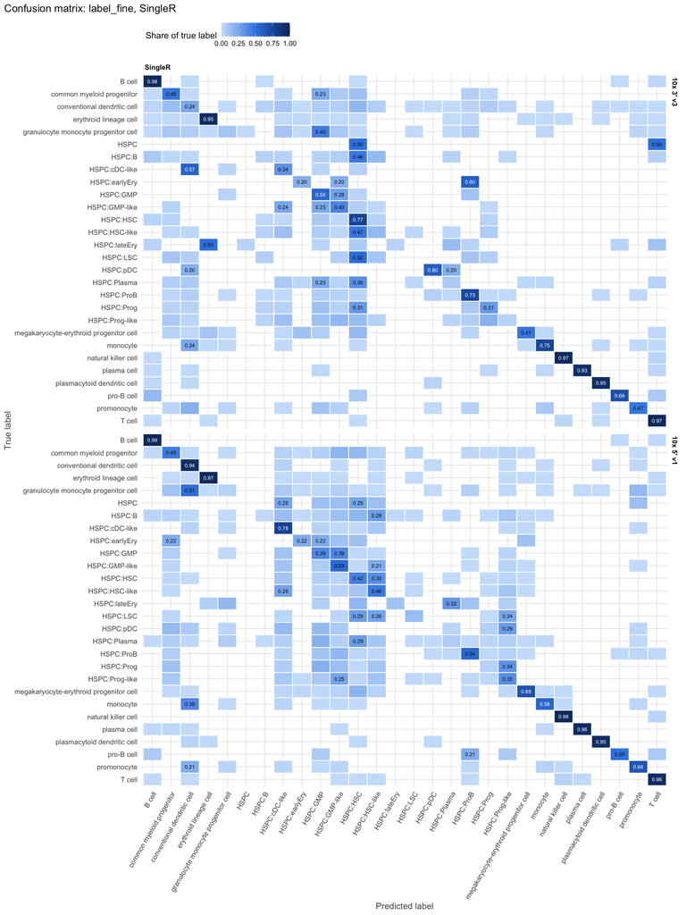

```r
by_level |>
  filter(level == "label_fine", method == "SingleR") |>
  plot_confusion("Confusion matrix: label_fine, SingleR")
```

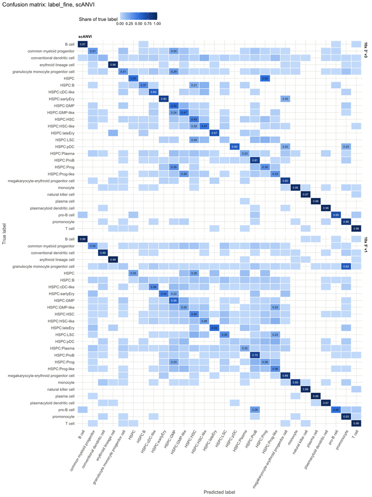

```r
by_level |>
  filter(level == "label_fine", method == "scANVI") |>
  plot_confusion("Confusion matrix: label_fine, scANVI")
```

## Per-donor accuracy

Overall accuracy for each donor and assay, to show how much performance varies across donors. Donors with fewer than 100 cells in an assay are left out.

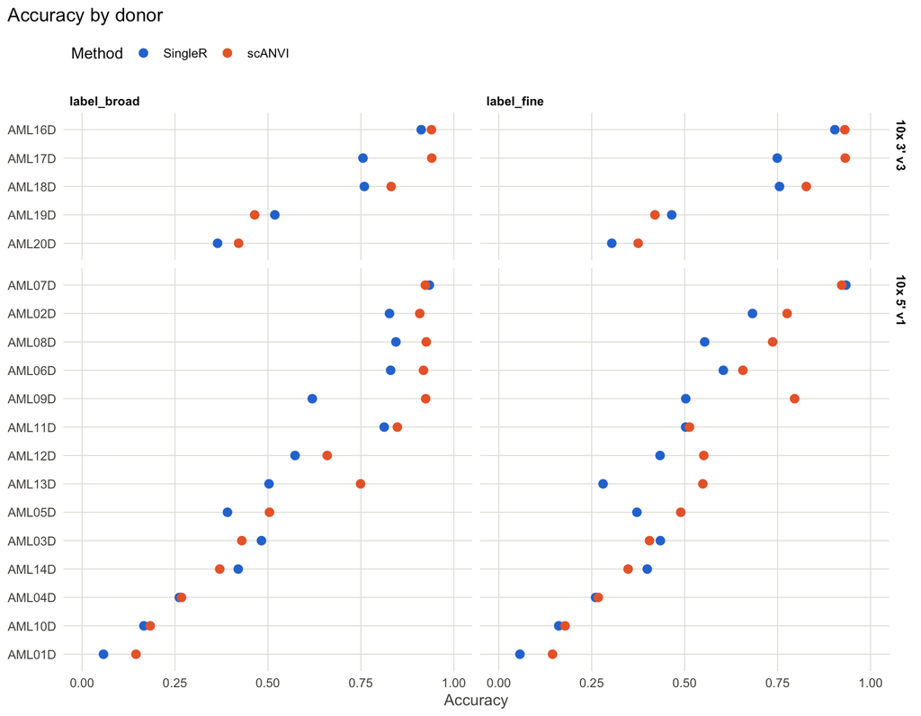

```r
donor_accuracy <- by_level |>
  group_by(method, assay, level, donor_id) |>
  summarize(n_cells = n(), accuracy = mean(correct), .groups = "drop") |>
  filter(n_cells >= 100)

donor_order <- donor_accuracy |>
  group_by(donor_id) |>
  summarize(mean_acc = mean(accuracy)) |>
  arrange(mean_acc) |>
  pull(donor_id)

donor_accuracy |>
  mutate(donor_id = factor(donor_id, levels = donor_order)) |>
  ggplot(aes(x = accuracy, y = donor_id, color = method)) +
  geom_point(size = 2.5) +
  facet_grid(assay ~ level, scales = "free_y", space = "free_y") +
  scale_x_continuous(limits = c(0, 1), breaks = seq(0, 1, 0.25)) +
  scale_color_method +
  labs(x = "Accuracy", y = NULL, title = "Accuracy by donor")
```

```r
donor_accuracy |>
  group_by(method, assay, level) |>
  summarize(
    n_donors = n(),
    min = min(accuracy),
    median = median(accuracy),
    max = max(accuracy),
    .groups = "drop"
  ) |>
  knitr::kable(digits = 3)
```

| method | assay | level | n_donors | min | median | max |
| --- | --- | --- | --- | --- | --- | --- |
| SingleR | 10x 3’ v3 | label_broad | 5 | 0.365 | 0.756 | 0.912 |
| SingleR | 10x 3’ v3 | label_fine | 5 | 0.304 | 0.749 | 0.904 |
| SingleR | 10x 5’ v1 | label_broad | 14 | 0.058 | 0.538 | 0.934 |
| SingleR | 10x 5’ v1 | label_fine | 14 | 0.057 | 0.434 | 0.934 |
| scANVI | 10x 3’ v3 | label_broad | 5 | 0.421 | 0.831 | 0.941 |
| scANVI | 10x 3’ v3 | label_fine | 5 | 0.375 | 0.827 | 0.932 |
| scANVI | 10x 5’ v1 | label_broad | 14 | 0.145 | 0.704 | 0.926 |
| scANVI | 10x 5’ v1 | label_fine | 14 | 0.145 | 0.531 | 0.922 |

## Confidence

### SingleR pruning

SingleR prunes (sets to `NA`) assignments whose score is an outlier for that label. How many cells are pruned, and how accurate are the remaining labels?

```r
singler_pruning <- singler |>
  inner_join(truth, by = "cell_id") |>
  mutate(pruned = is.na(singler_pruned_label)) |>
  left_join(label_map, by = c("singler_label" = "label_fine")) |>
  rename(pred_broad = label_broad)

singler_pruning |>
  group_by(assay) |>
  summarize(
    n_cells = n(),
    frac_pruned = mean(pruned),
    acc_fine_all = mean(singler_label == true_fine),
    acc_fine_kept = mean((singler_label == true_fine)[!pruned]),
    acc_broad_all = mean(pred_broad == true_broad),
    acc_broad_kept = mean((pred_broad == true_broad)[!pruned])
  ) |>
  knitr::kable(digits = 3)
```

| assay | n_cells | frac_pruned | acc_fine_all | acc_fine_kept | acc_broad_all | acc_broad_kept |
| --- | --- | --- | --- | --- | --- | --- |
| 10x 3’ v3 | 16119 | 0.002 | 0.623 | 0.624 | 0.652 | 0.652 |
| 10x 5’ v1 | 30469 | 0.001 | 0.439 | 0.439 | 0.534 | 0.534 |

Which true labels are pruned most often?

```r
singler_pruning |>
  group_by(assay, true_fine) |>
  summarize(n_cells = n(), frac_pruned = mean(pruned), .groups = "drop") |>
  arrange(desc(frac_pruned)) |>
  head(15) |>
  knitr::kable(digits = 3)
```

| assay | true_fine | n_cells | frac_pruned |
| --- | --- | --- | --- |
| 10x 5’ v1 | plasma cell | 224 | 0.022 |
| 10x 5’ v1 | HSPC:B | 242 | 0.021 |
| 10x 3’ v3 | plasma cell | 101 | 0.020 |
| 10x 3’ v3 | HSPC:B | 52 | 0.019 |
| 10x 3’ v3 | HSPC:Plasma | 56 | 0.018 |
| 10x 5’ v1 | HSPC:Plasma | 426 | 0.012 |
| 10x 3’ v3 | megakaryocyte-erythroid progenitor cell | 106 | 0.009 |
| 10x 5’ v1 | erythroid lineage cell | 830 | 0.005 |
| 10x 3’ v3 | erythroid lineage cell | 2265 | 0.004 |
| 10x 3’ v3 | conventional dendritic cell | 3812 | 0.003 |
| 10x 3’ v3 | granulocyte monocyte progenitor cell | 1441 | 0.003 |
| 10x 5’ v1 | common myeloid progenitor | 1763 | 0.002 |
| 10x 5’ v1 | HSPC:ProB | 489 | 0.002 |
| 10x 3’ v3 | T cell | 2607 | 0.000 |
| 10x 3’ v3 | monocyte | 3280 | 0.000 |

### scANVI probability threshold

If we only keep scANVI predictions whose maximum probability is at least a threshold, how do accuracy and the fraction of cells kept change? (Two measures, so two panels.)

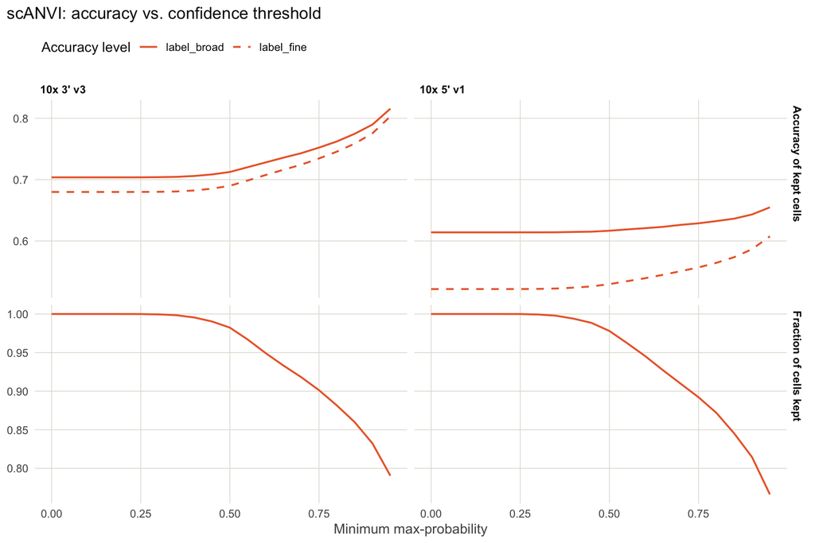

```r
scanvi_conf <- scanvi |>
  inner_join(truth, by = "cell_id") |>
  left_join(label_map, by = c("scanvi_label" = "label_fine")) |>
  rename(pred_broad = label_broad)

thresholds <- seq(0, 0.95, by = 0.05)

threshold_curve <- purrr::map(thresholds, \(t) {
  scanvi_conf |>
    group_by(assay) |>
    summarize(
      threshold = t,
      frac_kept = mean(scanvi_max_prob >= t),
      label_fine = mean((scanvi_label == true_fine)[scanvi_max_prob >= t]),
      label_broad = mean((pred_broad == true_broad)[scanvi_max_prob >= t]),
      .groups = "drop"
    )
}) |>
  purrr::list_rbind()

threshold_curve |>
  tidyr::pivot_longer(c(frac_kept, label_fine, label_broad), names_to = "measure") |>
  mutate(
    panel = if_else(measure == "frac_kept", "Fraction of cells kept", "Accuracy of kept cells"),
    measure = recode(measure, frac_kept = "kept")
  ) |>
  ggplot(aes(x = threshold, y = value, linetype = measure)) +
  geom_line(color = method_colors[["scANVI"]], linewidth = 0.7) +
  facet_grid(panel ~ assay, scales = "free_y") +
  scale_linetype_manual(
    values = c(label_broad = "solid", label_fine = "dashed", kept = "solid"),
    breaks = c("label_broad", "label_fine"),
    name = "Accuracy level"
  ) +
  labs(x = "Minimum max-probability", y = NULL, title = "scANVI: accuracy vs. confidence threshold")
```

## Malignancy proxy

The atlas’s only per-cell malignancy signal is the `-like`/`LSC` HSPC sub-labels (see `reference.md`). How often does each method call those cells `-like`/`LSC`, and how often does it call other cells `-like`/`LSC`?

- **Sensitivity:** share of true `-like`/`LSC` cells predicted as any `-like`/`LSC` label.
- **False-positive rate:** share of other cells predicted as `-like`/`LSC`.

```r
is_malignant_like <- function(label) grepl("-like$", label) | label == "HSPC:LSC"

predictions |>
  mutate(
    true_mal = is_malignant_like(true_fine),
    pred_mal = is_malignant_like(pred_fine)
  ) |>
  group_by(method, assay) |>
  summarize(
    n_true_mal = sum(true_mal),
    sensitivity = mean(pred_mal[true_mal]),
    false_positive_rate = mean(pred_mal[!true_mal]),
    precision = sum(pred_mal & true_mal) / sum(pred_mal),
    .groups = "drop"
  ) |>
  knitr::kable(digits = 3)
```

| method | assay | n_true_mal | sensitivity | false_positive_rate | precision |
| --- | --- | --- | --- | --- | --- |
| SingleR | 10x 3’ v3 | 373 | 0.418 | 0.079 | 0.111 |
| SingleR | 10x 5’ v1 | 2505 | 0.826 | 0.112 | 0.399 |
| scANVI | 10x 3’ v3 | 373 | 0.676 | 0.140 | 0.102 |
| scANVI | 10x 5’ v1 | 2505 | 0.629 | 0.079 | 0.416 |

Where do the true `-like`/`LSC` cells go? (Rows sum to 1 within method and assay.)

```r
predictions |>
  filter(is_malignant_like(true_fine)) |>
  count(method, assay, true_fine, pred_fine) |>
  group_by(method, assay, true_fine) |>
  mutate(share = n / sum(n)) |>
  slice_max(share, n = 3) |>
  ungroup() |>
  arrange(true_fine, assay, method, desc(share)) |>
  knitr::kable(digits = 3)
```

| method | assay | true_fine | pred_fine | n | share |
| --- | --- | --- | --- | --- | --- |
| SingleR | 10x 3’ v3 | HSPC:GMP-like | HSPC:GMP-like | 42 | 0.404 |
| SingleR | 10x 3’ v3 | HSPC:GMP-like | HSPC:cDC-like | 25 | 0.240 |
| SingleR | 10x 3’ v3 | HSPC:GMP-like | HSPC:GMP | 24 | 0.231 |
| scANVI | 10x 3’ v3 | HSPC:GMP-like | HSPC:GMP-like | 49 | 0.471 |
| scANVI | 10x 3’ v3 | HSPC:GMP-like | HSPC:GMP | 25 | 0.240 |
| scANVI | 10x 3’ v3 | HSPC:GMP-like | HSPC:HSC | 7 | 0.067 |
| scANVI | 10x 3’ v3 | HSPC:GMP-like | HSPC:cDC-like | 7 | 0.067 |
| SingleR | 10x 5’ v1 | HSPC:GMP-like | HSPC:GMP-like | 316 | 0.531 |
| SingleR | 10x 5’ v1 | HSPC:GMP-like | HSPC:HSC-like | 127 | 0.213 |
| SingleR | 10x 5’ v1 | HSPC:GMP-like | HSPC:cDC-like | 66 | 0.111 |
| scANVI | 10x 5’ v1 | HSPC:GMP-like | HSPC:GMP-like | 146 | 0.245 |
| scANVI | 10x 5’ v1 | HSPC:GMP-like | HSPC:Prog-like | 138 | 0.232 |
| scANVI | 10x 5’ v1 | HSPC:GMP-like | HSPC:GMP | 91 | 0.153 |
| SingleR | 10x 3’ v3 | HSPC:HSC-like | HSPC:HSC | 34 | 0.472 |
| SingleR | 10x 3’ v3 | HSPC:HSC-like | HSPC:HSC-like | 11 | 0.153 |
| SingleR | 10x 3’ v3 | HSPC:HSC-like | HSPC:cDC-like | 9 | 0.125 |
| scANVI | 10x 3’ v3 | HSPC:HSC-like | HSPC:HSC-like | 34 | 0.472 |
| scANVI | 10x 3’ v3 | HSPC:HSC-like | HSPC:HSC | 16 | 0.222 |
| scANVI | 10x 3’ v3 | HSPC:HSC-like | HSPC:LSC | 5 | 0.069 |
| SingleR | 10x 5’ v1 | HSPC:HSC-like | HSPC:HSC-like | 203 | 0.458 |
| SingleR | 10x 5’ v1 | HSPC:HSC-like | HSPC:cDC-like | 117 | 0.264 |
| SingleR | 10x 5’ v1 | HSPC:HSC-like | HSPC:Prog-like | 44 | 0.099 |
| scANVI | 10x 5’ v1 | HSPC:HSC-like | HSPC:HSC-like | 114 | 0.257 |
| scANVI | 10x 5’ v1 | HSPC:HSC-like | HSPC:Prog-like | 84 | 0.190 |
| scANVI | 10x 5’ v1 | HSPC:HSC-like | HSPC:LSC | 56 | 0.126 |
| SingleR | 10x 3’ v3 | HSPC:LSC | HSPC:HSC | 11 | 0.524 |
| SingleR | 10x 3’ v3 | HSPC:LSC | HSPC:HSC-like | 2 | 0.095 |
| SingleR | 10x 3’ v3 | HSPC:LSC | HSPC:ProB | 2 | 0.095 |
| SingleR | 10x 3’ v3 | HSPC:LSC | common myeloid progenitor | 2 | 0.095 |
| scANVI | 10x 3’ v3 | HSPC:LSC | HSPC:HSC | 5 | 0.238 |
| scANVI | 10x 3’ v3 | HSPC:LSC | HSPC:Prog | 4 | 0.190 |
| scANVI | 10x 3’ v3 | HSPC:LSC | HSPC:HSC-like | 3 | 0.143 |
| scANVI | 10x 3’ v3 | HSPC:LSC | HSPC:ProB | 3 | 0.143 |
| SingleR | 10x 5’ v1 | HSPC:LSC | HSPC:HSC | 91 | 0.290 |
| SingleR | 10x 5’ v1 | HSPC:LSC | HSPC:HSC-like | 82 | 0.261 |
| SingleR | 10x 5’ v1 | HSPC:LSC | HSPC:Prog-like | 75 | 0.239 |
| scANVI | 10x 5’ v1 | HSPC:LSC | HSPC:LSC | 111 | 0.354 |
| scANVI | 10x 5’ v1 | HSPC:LSC | HSPC:Prog-like | 71 | 0.226 |
| scANVI | 10x 5’ v1 | HSPC:LSC | HSPC:HSC | 59 | 0.188 |
| SingleR | 10x 3’ v3 | HSPC:Prog-like | HSPC:Prog | 24 | 0.186 |
| SingleR | 10x 3’ v3 | HSPC:Prog-like | HSPC:GMP-like | 20 | 0.155 |
| SingleR | 10x 3’ v3 | HSPC:Prog-like | HSPC:HSC | 18 | 0.140 |
| scANVI | 10x 3’ v3 | HSPC:Prog-like | HSPC:Prog-like | 42 | 0.326 |
| scANVI | 10x 3’ v3 | HSPC:Prog-like | HSPC:GMP-like | 39 | 0.302 |
| scANVI | 10x 3’ v3 | HSPC:Prog-like | HSPC:GMP | 11 | 0.085 |
| SingleR | 10x 5’ v1 | HSPC:Prog-like | HSPC:Prog-like | 346 | 0.355 |
| SingleR | 10x 5’ v1 | HSPC:Prog-like | HSPC:GMP-like | 246 | 0.252 |
| SingleR | 10x 5’ v1 | HSPC:Prog-like | HSPC:HSC-like | 101 | 0.103 |
| scANVI | 10x 5’ v1 | HSPC:Prog-like | HSPC:Prog-like | 356 | 0.365 |
| scANVI | 10x 5’ v1 | HSPC:Prog-like | HSPC:GMP-like | 144 | 0.148 |
| scANVI | 10x 5’ v1 | HSPC:Prog-like | HSPC:GMP | 122 | 0.125 |
| SingleR | 10x 3’ v3 | HSPC:cDC-like | conventional dendritic cell | 27 | 0.574 |
| SingleR | 10x 3’ v3 | HSPC:cDC-like | HSPC:cDC-like | 16 | 0.340 |
| SingleR | 10x 3’ v3 | HSPC:cDC-like | HSPC:HSC | 2 | 0.043 |
| scANVI | 10x 3’ v3 | HSPC:cDC-like | HSPC:cDC-like | 28 | 0.596 |
| scANVI | 10x 3’ v3 | HSPC:cDC-like | HSPC:HSC-like | 7 | 0.149 |
| scANVI | 10x 3’ v3 | HSPC:cDC-like | granulocyte monocyte progenitor cell | 3 | 0.064 |
| SingleR | 10x 5’ v1 | HSPC:cDC-like | HSPC:cDC-like | 138 | 0.780 |
| SingleR | 10x 5’ v1 | HSPC:cDC-like | HSPC:HSC-like | 15 | 0.085 |
| SingleR | 10x 5’ v1 | HSPC:cDC-like | HSPC:GMP | 8 | 0.045 |
| scANVI | 10x 5’ v1 | HSPC:cDC-like | HSPC:cDC-like | 67 | 0.379 |
| scANVI | 10x 5’ v1 | HSPC:cDC-like | HSPC:GMP | 25 | 0.141 |
| scANVI | 10x 5’ v1 | HSPC:cDC-like | HSPC:GMP-like | 21 | 0.119 |